# 04 Prove - Assignment

## Objectives

- In this project, you will create a personal collage of images.

## Overview of Project

For this project, you will be creating a personal collage of images.

Here are some examples of image collages

Example 1

Example 2

Example 3

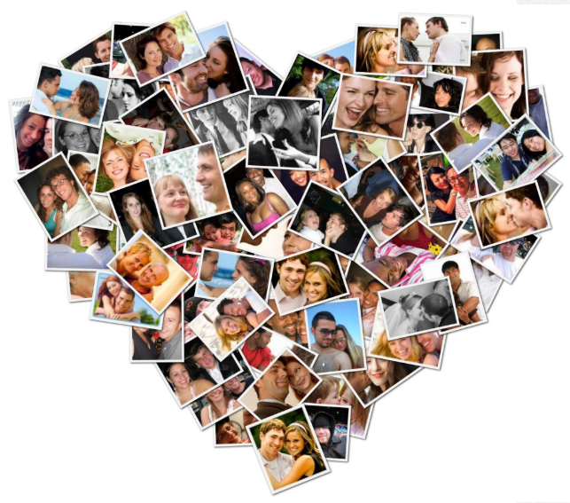

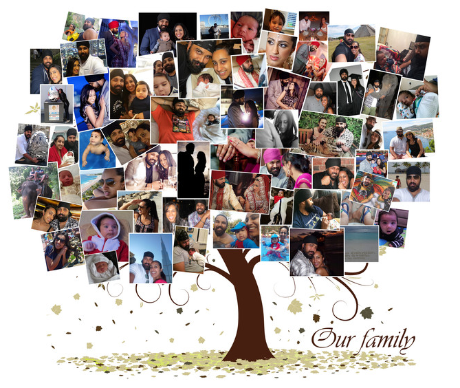

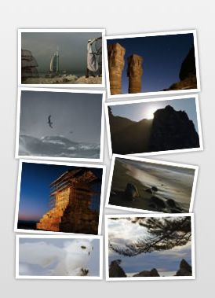

## Instructions

Your project code must create a final image collage from other images.

- You are free to use any OpenCV and numpy function for this project. Note, I might ask you to explain any part of your project if I feel that you copied code samples from the Internet.
- You **must show** that you were able to:
  - scale images
  - rotate images
  - position images in the final collage
  - add borders to images
- You must overlap images with each other.
- The background image of the collage is up to you.
- The number of images in your collage is up to you. However, presentation is important. (ie., a one image collage is not worth anything). The least number of images is 10.
- Please use your own images that you have taken from your cell phone (Borrow ad phone if you don't have one). These images can be of anything (ie., family, nature, building, etc...) You are allowed to take stock images from the Internet too.

## Hints

1. Choose the size of your images that you add into your project wisely.
2. Create functions that will adjust or modify images - don't write one large function to do the whole project.

## Rubric

Assignments are not accepted late. Instead, you should submit what you have completed by the due date for partial credit. The Assignment will be graded in broad categories according to the following:

| grade | Description |
| --- | --- |
| 0% | Nothing submitted |
| 50% | Some attempt made |
| 75% | Developing (but significantly deficient) |
| 85% | Slightly deficient |
| 93% | Meets requirements |
| 100% | Showed creativity and extend your assignments beyond the minimum standard that is specifically required |

## Submission

1. Upload your project Python code that creates your collage.
2. Upload the final image of the completed collage in PNG format.
3. **Do not** upload a ZIP file of the two files.
4. **Do not** submit the images used in creating your collage.